# Powerlifting: An Exploration on the Data

Zach Eanes & Dalton Rogers

2024-05-07

# What is “Powerlifting”?

As an easy description, powerlifting is the open sport of competing to see who can lift the most total weight across three primary lifts. These lifts being Squat, Bench, and Deadlift (referred to as SBD throughout this project).

The general structure of many of these competitions includes many little factors: 1) Everyone is split into weight classes, gender, and age classes. This is to ensure everyone is competing fairly and no one has a clear advantage. 2) Every lifter has 3 attempts for each lifting, leaving 9 total lifts across the competition. 3) Drug free! No steroids or substances that may boost someone’s performance, and these competitors are tested to ensure they are drug free. 4) The concept of good and failed lifts: There’s 3 judges for a lift, all viewing a different perspective of the lifter. In order for a lift to be good, 2/3 judges must deem it a good lift. Some common failures include not getting enough depth squatting, not controlling the drop after a deadlift, or of course literally not getting the weight up.

# Linear Progression of Weight Classes? (Section 1)

This one is simple, do heavier weights classes generally lift higher amounts than lower? We can observe the best successful lift for each SBD and find an average for each weight class group and then we can compare the classes to see if there’s a linear progression.

IPF lists their male weight classes as: 59.0 kg Class: up to 59.0 kg 66.0 kg Class: from 59.01 kg up to 66.0 kg 74.0 kg Class: from 66.01 kg up to 74.0 kg 83.0 kg Class: from 74.01 kg up to 83.0 kg 93.0 kg Class: from 83.01 kg up to 93.0 kg 105.0 kg Class: from 93.01 kg up to 105.0 kg 120.0 kg Class: from 105.01 kg up to 120.0 kg 120.0+ kg Class: from 120.01 kg up to unlimited

IPF lists their female weight classes as: 47.0 kg Class: up to 47.0 kg 52.0 kg Class: from 47.01 kg up to 52.0 kg 57.0 kg Class: from 52.01 kg up to 57.0 kg 63.0 kg Class: from 57.01 kg up to 63.0 kg 69.0 kg Class: from 63.01 kg up to 69.0 kg 76.0 kg Class: from 69.01 kg up to 76.0 kg 84.0 kg Class: from 76.01 kg up to 84.0 kg 84.0+ kg Class: from 84.01 kg up to unlimited

```r
# get those in proper weight classes, and make weight_class_kg a factor for organization
male_factors = c(59, 66, 74, 83, 93, 105, 120, "120+")
male_classes <- ipf |>
    filter(weight_class_kg %in% c(59, 66, 74, 83, 93, 105, 120, "120+") & sex == "M") |>
    mutate(weight_class_kg = factor(weight_class_kg, levels = male_factors))

female_factors = c(47, 52, 57, 63, 69, 76, 84, "84+")
female_classes <- ipf |>
    filter(weight_class_kg %in% c(47, 52, 57, 63, 69, 76, 84, "84+") & sex == "F") |>
    mutate(weight_class_kg = factor(weight_class_kg, levels = female_factors))



# This function gets the average of the best lift for each factor and arranges it
# by the weight class itself
#
# Args: class - the class we want to get the average weights for
avg_weights <- function(class) {
    class |>
    filter(!is.na(best3squat_kg) & !is.na(best3bench_kg) & !is.na(best3deadlift_kg)) |>
        group_by(weight_class_kg) |> # group by their respective classes
        summarize(
            avg_squat = sum(best3squat_kg) / n(), # get avg squat
            avg_bench = sum(best3bench_kg) / n(), # get avg bench
            avg_dead = sum(best3deadlift_kg) / n()) |> # get avg deadlift
        arrange(weight_class_kg) # arrange to make it better
}

# This function takes our data and makes the data itself tidier and simple to use for
# both data exploration and graphing.
#
# Args: class - the class we want to make tidier
make_avgs_tidyer <- function(class) {
    # pivot to long format to graph easier
    class |> pivot_longer(cols = c(avg_squat, avg_bench, avg_dead),
                          names_to = "lift", values_to = "avg_weight")
}

# get information we need for our data and make it usable
weights_male <- avg_weights(male_classes) |> make_avgs_tidyer(); weights_male
```

```
## # A tibble: 24 × 3
##    weight_class_kg lift      avg_weight
##    <fct>           <chr>          <dbl>
##  1 59              avg_squat      136.
##  2 59              avg_bench       88.5
##  3 59              avg_dead       158.
##  4 66              avg_squat      156.
##  5 66              avg_bench      103.
##  6 66              avg_dead       181.
##  7 74              avg_squat      174.
##  8 74              avg_bench      115.
##  9 74              avg_dead       201.
## 10 83              avg_squat      190.
## # ℹ 14 more rows
```

```r
weights_female <- avg_weights(female_classes) |> make_avgs_tidyer(); weights_female
```

```
## # A tibble: 24 × 3
##    weight_class_kg lift      avg_weight
##    <fct>           <chr>          <dbl>
##  1 47              avg_squat       90.7
##  2 47              avg_bench       51.5
##  3 47              avg_dead       107.
##  4 52              avg_squat      102.
##  5 52              avg_bench       57.1
##  6 52              avg_dead       118.
##  7 57              avg_squat      106.
##  8 57              avg_bench       60.3
##  9 57              avg_dead       125.
## 10 63              avg_squat      111.
## # ℹ 14 more rows
```

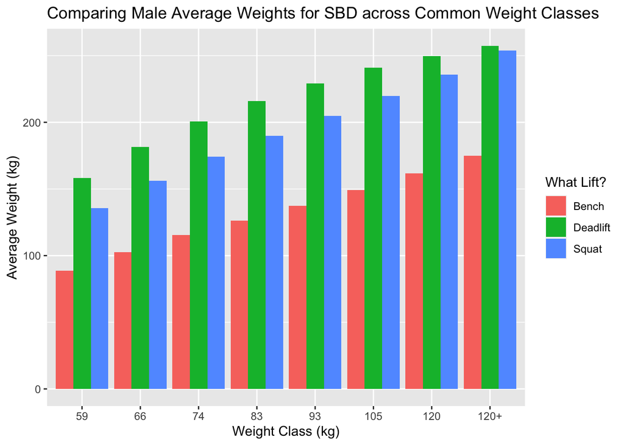

```r
# group by the weight class and put sbd all next to each other in group
weights_male |> ggplot(aes(x = weight_class_kg, y = avg_weight, fill = lift)) +
    geom_bar(stat = "identity", position = "dodge") +
    labs(
        title = "Comparing Male Average Weights for SBD across Common Weight Classes",
        x = "Weight Class (kg)",
        y = "Average Weight (kg)"
    ) + scale_fill_discrete(name = "What Lift?", labels = c("Bench", "Deadlift", "Squat"))
```

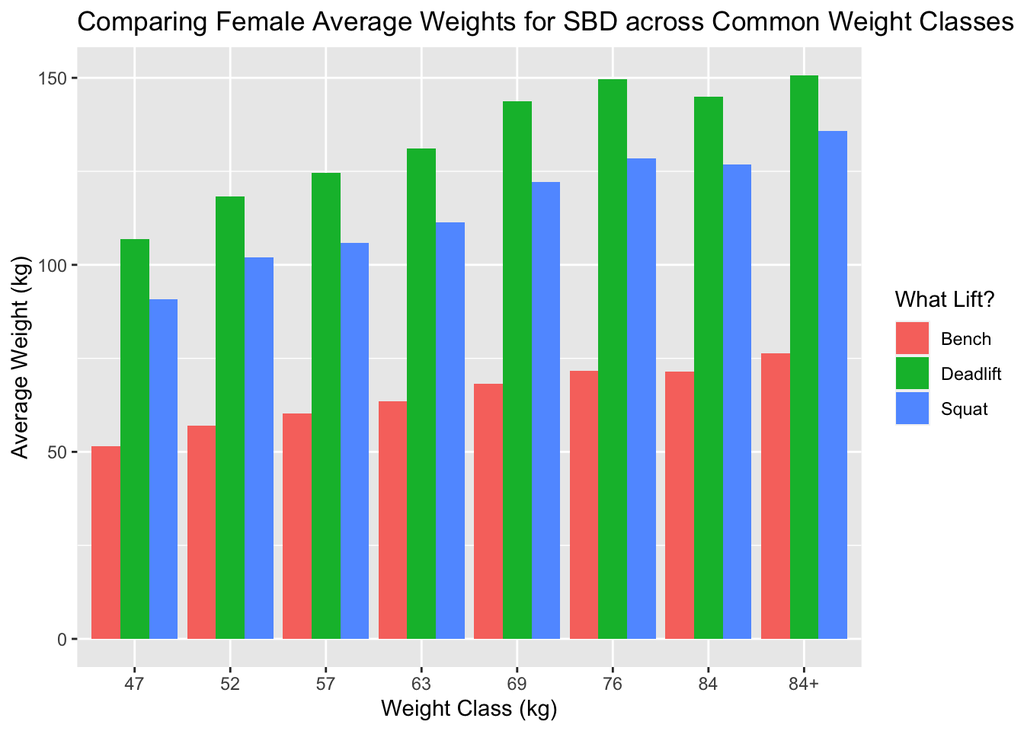

```r
weights_female |> ggplot(aes(x = weight_class_kg, y = avg_weight, fill = lift)) +
    geom_bar(stat = "identity", position = "dodge") +
    labs(
        title = "Comparing Female Average Weights for SBD across Common Weight Classes",
        x = "Weight Class (kg)",
        y = "Average Weight (kg)"
    ) + scale_fill_discrete(name = "What Lift?", labels = c("Bench", "Deadlift", "Squat"))
```

In order to get this information together, we had many failures and attempts at using the data is a less tidy manner. The biggest change was the inclusion of the pivot_longer in order to allow us to create more rows and make the graphing easier. It allows us to group and place each lift inside of the group, as well as creating a cleaner chart in general. Beforehand, we broke some of the basic policies of tidy data, including storing too much information inside of a cell and “double dipping”. We had numbers in the columns for the lift itself, and in the end out newest form is tidiest and surely best for our purposes. Below is some of the attempts we had beforehand, which ended as a failure in all honesty.

```r
# below method is an early attempt that ended in failure
pre_avg_weights <- function(class) {
    class |>  # filter out any entry missing the best lift
        filter(!is.na(best3squat_kg) & !is.na(best3bench_kg) & !is.na(best3deadlift_kg)) |>
        group_by(weight_class_kg) |> # group by their respective classes
        summarize(
            avg_squat = sum(best3squat_kg) / n(), # get avg squat
            avg_bench = sum(best3bench_kg) / n(), # get avg bench
            avg_dead = sum(best3deadlift_kg) / n()) |> # get avg deadlift
        arrange(weight_class_kg)
}

# recreate our data set for demonstration purposes
male_classes <- ipf |>
    filter(weight_class_kg %in% c(59, 66, 74, 83, 93, 105, 120, "120+") & sex == "M") |>
    mutate(weight_class_kg = factor(weight_class_kg,
                                       levels = male_factors))
# this was the dataset before
pre_avg_weights(male_classes)
```

```
## # A tibble: 8 × 4
##   weight_class_kg avg_squat avg_bench avg_dead
##   <fct>               <dbl>     <dbl>    <dbl>
## 1 59                   136.      88.5     158.
## 2 66                   156.     103.      181.
## 3 74                   174.     115.      201.
## 4 83                   190.     126.      216.
## 5 93                   205.     137.      229.
## 6 105                  220.     149.      241.
## 7 120                  236.     162.      250.
## 8 120+                 254.     175.      257.
```

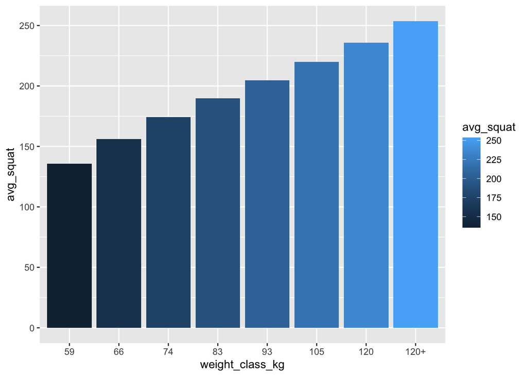

```r
# this was out plot before the pivot_longer, as we just had each lift in thier own graph
pre_avg_weights(male_classes) |> ggplot(aes(x = weight_class_kg, y = avg_squat, fill = avg_squat)) +
    geom_bar(stat = "identity")
```